# TOD Study in Newyork

Minwook KANG

2022-09-23

## Ⅰ. Introduction

New Yorkers use the subway the most than any other city in the United States. Is this because of the dense existing transportation network in New York City, which has a long history, or do people actually prefer to live near subway stations? In fact, Seoul and Tokyo, where many TOD developments are successful, typically see property values rise as they get closer to the station, and it is easy to see people also living near the station and enjoying programs in cities that are relatively denser than other regions. What about New York? Are New Yorkers willing to pay higher rents to live near subway stations? This research was based on a subway infrastructure that stretched from Manhattan to Brooklyn, Queens, and the Bronx.

Chapter 2 introduces the process of data collection and processing for research. Following Chapter 3 visualizes and charts major variables such as income, population, and rent over time to observe changes in TOD and Non-TOD areas between 2009 and 2019. Chapter 4 examines the total population, average rent, and average income based on each subway station and look the differences within the TOD area. Finally, in Chapter 5, we’re going to use the graph that shows mean rent as a function of distance to each station to gather in-depth information.

## Ⅱ. Setup

This chapter describes technical contents form several libraries, Plot themes to Functions used throughout the research.

```r
# Rmarkdown global setting
knitr::opts_chunk$set(echo = TRUE)
knitr::opts_chunk$set(message = FALSE)
knitr::opts_chunk$set(warning = FALSE)
knitr::opts_chunk$set(cache = TRUE)
knitr::opts_chunk$set(fig.align = 'center')

# Import libraries
library(tidyverse)
library(tidycensus)
library(sf)
library(kableExtra)
library(gridExtra)
library(grid)
library(knitr)
library(rmarkdown)
library(RSocrata)
library(viridis)
library(ggplot2)

# Etc
options(scipen=999)
options(tigris_class = "sf")

# functions
min_mapTheme <- function(base_size = 10, title_size = 12, small_size = 8) {
  theme(
    text = element_text( color = "black"),
    plot.title = element_text(size = title_size, colour = "black", hjust = 0.5),
    plot.subtitle=element_text(size = base_size, colour = "black", hjust = 0.5, face="italic"),
    plot.caption=element_text(size = small_size, colour = "black", hjust = 0.5),
    axis.ticks = element_blank(),
    axis.title = element_blank(),
    axis.text = element_blank(),
    axis.title.x = element_blank(),
    axis.title.y = element_blank(),
    panel.background = element_blank(),
    panel.grid.minor = element_blank(),
    panel.border = element_blank(),
    strip.text.x = element_text(size = base_size),
    strip.text.y = element_text(size = base_size),
    strip.background = element_rect(colour="transparent", fill="transparent"),
    legend.title = element_text(size = small_size),
    legend.text = element_text(size = small_size),
    legend.key.size = unit(0.4, "cm"))
}


min_plotTheme <- function(base_size = 10, title_size = 12, small_size = 8) {
  theme(
    text = element_text( color = "black"),
    plot.title = element_text(size = title_size, colour = "black", hjust = 0.5),
    plot.subtitle = element_text(size = base_size, colour = "black", hjust = 0.5, face="italic"),
    plot.caption = element_text(size = small_size, colour = "black", hjust = 0.5),
    strip.text.x = element_text(size = base_size),
    strip.text.y = element_text(size = base_size),
    strip.background = element_rect(colour="transparent", fill="transparent"),
    axis.title = element_text(size=base_size),
    axis.text = element_text(size=small_size),
    panel.background = element_blank(),
    legend.title = element_text(size = small_size, colour = "black"),
    legend.text = element_text(size = small_size, colour = "black"),
    legend.position="bottom",
    legend.key.size = unit(0.4, "cm")
  )
}

q5 <- function(variable) {as.factor(ntile(variable, 5))}

qBr <- function(df, variable, rnd) {
  if (missing(rnd)) {
    as.character(quantile(round(df[[variable]],0),
                          c(.01,.2,.4,.6,.8), na.rm=T))
  } else if (rnd == FALSE | rnd == F) {
    as.character(formatC(quantile(df[[variable]],
                                  c(.01,.2,.4,.6,.8), na.rm=T),
                         digits = 3))
  }
}

MBR <- function(inputPolygon, maxDistance, interval) {
  #create a list of distances that we'll iterate through to create each ring
  distances <- seq(0, maxDistance, interval)
  #we'll start with the second value in that list - the first is '0'
  distancesCounter <- 2
  #total number of rings we're going to create
  numberOfRings <- floor(maxDistance / interval)
  #a counter of number of rings
  numberOfRingsCounter <- 1
  #initialize an otuput data frame (that is not an sf)
  allRings <- data.frame()

  #while number of rings  counteris less than the specified nubmer of rings
  while (numberOfRingsCounter <= numberOfRings)
  {
    #if we're interested in a negative buffer and this is the first buffer
    #(ie. not distance = '0' in the distances list)
    if(distances[distancesCounter] < 0 & distancesCounter == 2)
    {
      #buffer the input by the first distance
      buffer1 <- st_buffer(inputPolygon, distances[distancesCounter])
      #different that buffer from the input polygon to get the first ring
      buffer1_ <- st_difference(inputPolygon, buffer1)
      #cast this sf as a polygon geometry type
      thisRing <- st_cast(buffer1_, "POLYGON")
      #take the last column which is 'geometry'
      thisRing <- as.data.frame(st_geometry(thisRing))
      #add a new field, 'distance' so we know how far the distance is for a give ring
      thisRing$distance <- distances[distancesCounter]
    }


    #otherwise, if this is the second or more ring (and a negative buffer)
    else if(distances[distancesCounter] < 0 & distancesCounter > 2)
    {
      #buffer by a specific distance
      buffer1 <- st_buffer(inputPolygon, distances[distancesCounter])
      #create the next smallest buffer
      buffer2 <- st_buffer(inputPolygon, distances[distancesCounter-1])
      #This can then be used to difference out a buffer running from 660 to 1320
      #This works because differencing 1320ft by 660ft = a buffer between 660 & 1320.
      #bc the area after 660ft in buffer2 = NA.
      thisRing <- st_difference(buffer2,buffer1)
      #cast as apolygon
      thisRing <- st_cast(thisRing, "POLYGON")
      #get the last field
      thisRing <- as.data.frame(st_geometry(thisRing))
      #create the distance field
      thisRing$distance <- distances[distancesCounter]
    }

    #Otherwise, if its a positive buffer
    else
    {
      #Create a positive buffer
      buffer1 <- st_buffer(inputPolygon, distances[distancesCounter])
      #create a positive buffer that is one distance smaller. So if its the first buffer
      #distance, buffer1_ will = 0.
      buffer1_ <- st_buffer(inputPolygon, distances[distancesCounter-1])
      #difference the two buffers
      thisRing <- st_difference(buffer1,buffer1_)
      #cast as a polygon
      thisRing <- st_cast(thisRing, "POLYGON")
      #geometry column as a data frame
      thisRing <- as.data.frame(st_geometry(thisRing))
      #add teh distance
      thisRing$distance <- distances[distancesCounter]
    }

    #rbind this ring to the rest of the rings
    allRings <- rbind(allRings, thisRing)
    #iterate the distance counter
    distancesCounter <- distancesCounter + 1
    #iterate the number of rings counter
    numberOfRingsCounter <- numberOfRingsCounter + 1
  }

  #convert the allRings data frame to an sf data frame
  allRings <- st_as_sf(allRings)
}


# Colors
bluePalette5 <- c("#eff3ff","#bdd7e7","#6baed6","#3182bd","#08519c")
orangePalette5 <- c("#ffffb2","#fecc5c","#fd8d3c","#f03b20","#bd0026")
greyPalette5 <- c("#f7f7f7","#cccccc","#969696","#636363","#252525")

# LoadAPI
census_api_key("4bbe4bead4e5817f6a6b79e62c5bea69e77f1887", overwrite = TRUE)

# Temp
source("https://raw.githubusercontent.com/urbanSpatial/Public-Policy-Analytics-Landing/master/functions.r")
```

## Ⅲ. Analysis

### 3-1. Data Wrangling

The study used census data and subway data provided by New York City.

#### 3-1-1. Census Data Manipulation

Census data compared changes using 2009 and 2019 data, and inflation figures were applied to the money-related variables in 2009. The data used in this study are as follows.

- Total Population, Median House Hold Income, Median Rent, Percent of White, Percent of Bachelors, Percent of Poverty, Percent of Vacant Housing, Population Density

#### 3-1-2. Import Newyork Subway Staion Data

According to Geojson Data, there are 473 subway stations in New York City(https://data.cityofnewyork.us/api/geospatial/arq3-7z49?method=export&format=GeoJSON). However, some transfer stations as two or more stations, which are called station complexes within the New York City Subway counted more than once. If station complexes are counted as one station each, the number of stations is 424.

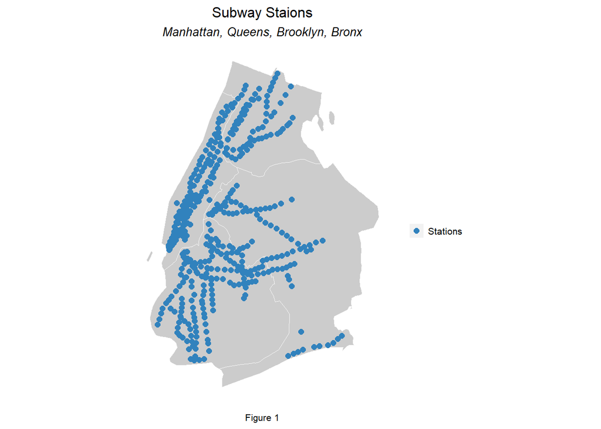

```r
# Newyork Transit Stops Data

ggplot() +
  geom_sf(data=st_union(tracts09_MH), fill = greyPalette5[2], size = 0.3, color = greyPalette5[1]) +
  geom_sf(data=st_union(tracts09_QS), fill = greyPalette5[2], size = 0.3, color = greyPalette5[1]) +
  geom_sf(data=st_union(tracts09_BR), fill = greyPalette5[2], size = 0.3, color = greyPalette5[1]) +
  geom_sf(data=st_union(tracts09_BK), fill = greyPalette5[2], size = 0.3, color = greyPalette5[1]) +
  geom_sf(data=NYStops,
          aes(colour = bluePalette5[4]),
          show.legend = "point", size= 2) +
  scale_colour_manual(values = c(bluePalette5[4]),
                      labels = 'Stations',
                      name = ' ') +
  labs(title="Subway Staions",
       subtitle="Manhattan, Queens, Brooklyn, Bronx",
       caption="Figure 1") +
  min_mapTheme()
```

#### 3-1-3. Define TOD, non-TOD area of Newyork

In this study, Transit-Oriented Development area, or TOD for short, is set within half a mile of the station. If the center point of each census tract is included within 0.5 miles from the subway station, it is defined as TOD area, and if it is outside, it is designated as Non-TOD area. There are a total of 2057 census Tracts in the studied area, of which 1,378 (66%) are included in the TOD area. Due to the dense subway infrastructure, it is confirmed that many areas are TOD. **As of 2019, the total population of the survey area was 7.76 million, with 5.68 million (73%) residing in TOD and 2.08 million (27%) residing in the Non-TOD area. It can be seen that a relatively large population lives in the TOD area.**

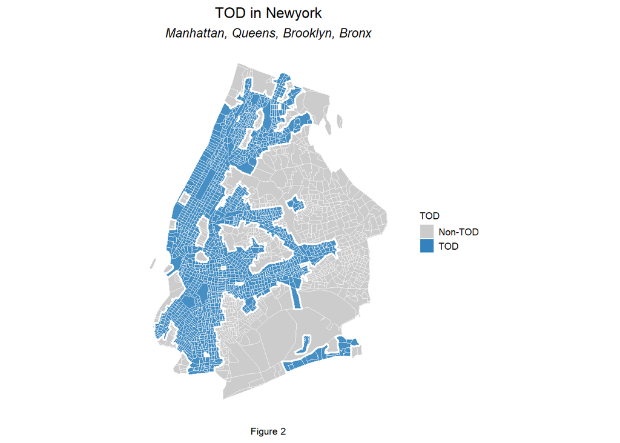

```r
# Creat Buffers

NYStopsBuffers <-
  st_union(st_buffer(NYStops, 2640)) %>%
  st_sf() %>%
  st_transform('EPSG:2263')

# Define TOD, non-TOD tracts of NewYork

allTracts_TOD <-
  rbind(
    st_centroid(allTracts)[NYStopsBuffers,] %>%
      st_drop_geometry() %>%
      left_join(allTracts) %>%
      st_sf() %>%
      mutate(TOD = "TOD"),
    st_centroid(allTracts)[NYStopsBuffers, op = st_disjoint] %>%
      st_drop_geometry() %>%
      left_join(allTracts) %>%
      st_sf() %>%
      mutate(TOD = "Non-TOD"))

#allTracts_TOD %>%
  #filter(TOD == "TOD",year == "2019")%>%
  #summary()

ggplot(allTracts_TOD)+
  geom_sf(aes(fill = TOD), color = greyPalette5[1], size = 0.05) +
  scale_fill_manual(values = c(greyPalette5[2], bluePalette5[4])) +
  geom_sf(data = allTracts_TOD %>%
            filter(TOD == "TOD") %>%
            st_union(), color = "white", fill = "transparent", alpha = 0.1, size = 0.8)+
  labs(title = "TOD in Newyork",
       subtitle = "Manhattan, Queens, Brooklyn, Bronx",
       caption = "Figure 2") +
  min_mapTheme()
```

### 3-2. Changes across Time and Spcae

#### 3-2-1. Poplation Density Change between 2009 and 2019

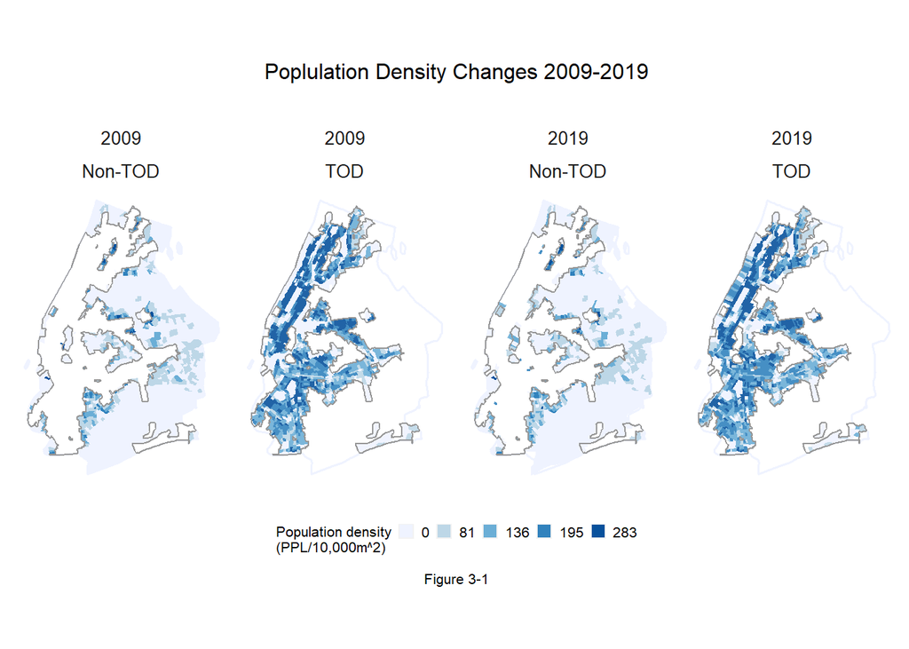

```r
ggplot(allTracts_TOD)+
  geom_sf(data = st_union(tracts09), color = bluePalette5[1], fill = "transparent", size = 0.7 )+
  geom_sf(aes(fill = q5(Popdensity)), color = "transparent" ) +
  scale_fill_manual(values = bluePalette5,
                    labels = qBr(allTracts_TOD, "Popdensity"),
                    name = "Population density\n(PPL/10,000m^2)",
                    na.translate=FALSE) +
  geom_sf(data = allTracts_TOD %>%
            filter(TOD == "TOD") %>%
            st_union(), color = greyPalette5[3], fill = "transparent", alpha = 0.1, size = 0.5) +
  labs(title = "Poplulation Density Changes 2009-2019",
       subtitle = " ",
       caption = 'Figure 3-1') +
  facet_wrap(c(~year, ~TOD), ncol=4) +
  min_mapTheme()+
  theme(legend.key.size = unit(0.3, "cm"),
        legend.position="bottom")
```

#### 3-2-2. Median Rent Change between 2009 and 2019 with Inflation rate

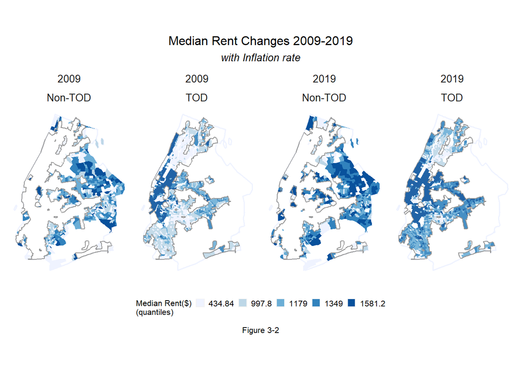

```r
ggplot(allTracts_TOD)+
  geom_sf(data = st_union(tracts09), color = bluePalette5[1], fill = "transparent", size = 0.7 )+
  geom_sf(aes(fill = q5(MedRent)), color = "transparent" ) +
  scale_fill_manual(values = bluePalette5,
                    labels = qBr(allTracts_TOD, "MedRent"),
                    name = "Median Rent($)\n(quantiles)",
                    na.translate=FALSE) +
  geom_sf(data = allTracts_TOD %>%
            filter(TOD == "TOD") %>%
            st_union(), color = greyPalette5[3], fill = "transparent", alpha = 0.1, size = 0.5) +
  labs(title = "Median Rent Changes 2009-2019",
       subtitle = "with Inflation rate",
       caption = 'Figure 3-2') +
  facet_wrap(c(~year, ~TOD), ncol=4) +
  min_mapTheme()+
  theme(legend.key.size = unit(0.3, "cm"),
        legend.position="bottom")
```

#### 3-2-3. Median House Hold Income Change between 2009 and 2019 with Inflation rate

In the case of House Income, the results are almost similar to ‘3-2-2. Median Rent Change between 2009 and 2019 with Inflation rate’. Similarly, it is necessary to check the details in ‘3-3-1. Summary Table comparisons’ through detailed data numerical comparisons.

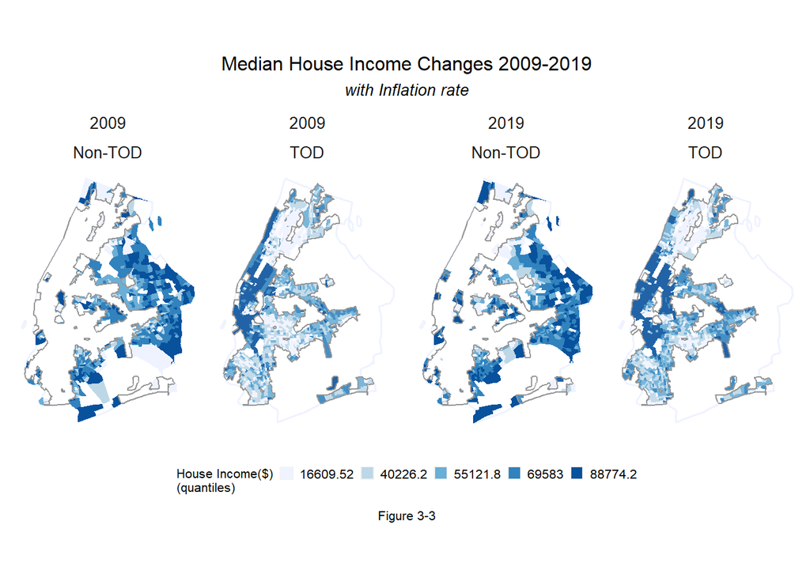

```r
ggplot(allTracts_TOD)+
  geom_sf(data = st_union(tracts09), color = bluePalette5[1], fill = "transparent", size = 0.7 )+
  geom_sf(aes(fill = q5(MedHHInc)), color = "transparent" ) +
  scale_fill_manual(values = bluePalette5,
                    labels = qBr(allTracts_TOD, "MedHHInc"),
                    name = "House Income($)\n(quantiles)",
                    na.translate=FALSE) +
  geom_sf(data = allTracts_TOD %>%
            filter(TOD == "TOD") %>%
            st_union(), color = greyPalette5[3], fill = "transparent", alpha = 0.1, size = 0.5) +
  labs(title = "Median House Income Changes 2009-2019",
       subtitle = "with Inflation rate",
       caption = 'Figure 3-3') +
  facet_wrap(c(~year, ~TOD), ncol=4)+
  min_mapTheme()+
  theme(legend.key.size = unit(0.3, "cm"),
        legend.position="bottom")
```

#### 3-2-4. Percentage of Vacant House Changes between 2009 and 2019

According to the Figure 3-4, There did not seem to be a large difference between TOD and Non-TOD, and over time, the gap between the two regions does not seem to decrease or increase. It is necessary to check the details in ‘3-3-1. Summary Table comparisons’ through detailed data numerical comparisons.

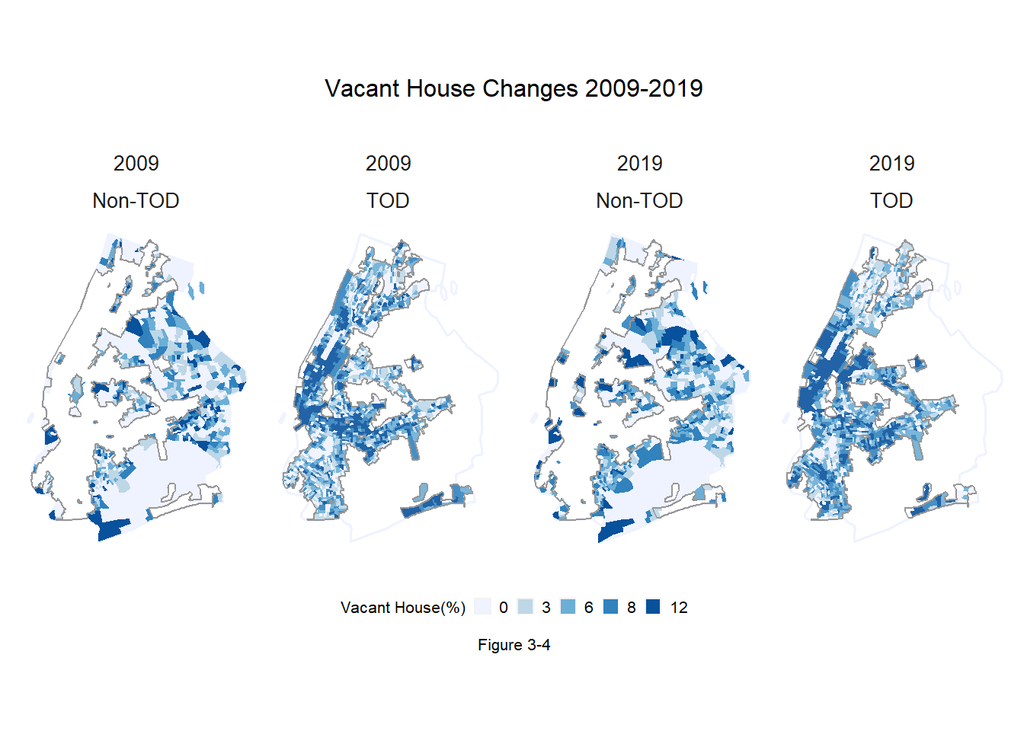

```r
ggplot(allTracts_TOD)+
  geom_sf(data = st_union(tracts09), color = bluePalette5[1], fill = "transparent", size = 0.7 )+
  geom_sf(aes(fill = q5(pctVacnant)), color = "transparent" ) +
  scale_fill_manual(values = bluePalette5,
                    labels = qBr(allTracts_TOD, "pctVacnant"),
                    name = "Vacant House(%)",
                    na.translate=FALSE) +
  geom_sf(data = allTracts_TOD %>%
            filter(TOD == "TOD") %>%
            st_union(), color = greyPalette5[3], fill = "transparent", alpha = 0.1, size = 0.5) +
  labs(title = "Vacant House Changes 2009-2019",
       subtitle = "",
       caption = 'Figure 3-4') +
  facet_wrap(c(~year, ~TOD), ncol=4)+
  min_mapTheme()+
  theme(legend.key.size = unit(0.3, "cm"),
        legend.position="bottom")
```

### 3-3. Comparison of Census Variables

In this chapter, we would like to derive various meanings from the chart comparing the actual numbers.

#### 3-3-1. Summary Table comparisons

- **Income :** In both 2009 and 2019, non-TOD had a higher median income than TOD. However, income in the TOD region rose by 14% over the decade, while income in the Non-TOD region rose by only 1.4%. **This shows a significant increase of income in the TOD region.**
- **Percent_Bach :** The proportion of college students living in TOD areas has increased over time. **For college students, it seems clear that the subway infrastructure in New York is working as a good option to improve their accessibility.**
- Percent_Vacant : Percent of Vacant Housing in TOD and Non-TOD areas does not seem to change much. The overall increase in Vacant Housing over time seems to have other market factors.
- **Percent_White :** In general, the proportion of White was always high in TOD areas. **In addition, over time, the gap between TOD and non-TOD areas’ white ratio is large, indicating that the season’s preference for TOD increases.**
- **Population :** The number of people living in TOD areas has always been higher than non-TOD areas. Over time, the total population of residents increases, but the differences between regions do not widen to a significant level. **It is expected that there will be more residents in TOD areas in the future.**
- **Population_density :** For population density, TOD regions show a higher rise. It seems that many people tend to prefer to live in TOD areas.
- **Rent :** In 2009, rents in non-TOD areas were higher than those in TOD areas. But in 2019, the situation have reversed, with people living in TOD areas paying more rent than those living in Non-TOD areas. The rent increase in the non-TOD area was only 14%, while the rent increase in the TOD area was 25%, almost twice. **It seems clear that New Yorkers are willing to pay more rent to live in TOD.**

```r
#

allTracts_Summary <-
  st_drop_geometry(allTracts_TOD) %>%
  group_by(year, TOD) %>%
  summarize(Rent = mean(MedRent, na.rm = T),
            Income = mean(MedHHInc, na.rm = T),
            Population = mean(TotalPop, na.rm = T),
            Population_density  = mean(Popdensity, na.rm = T),
            Percent_White = mean(pctWhite, na.rm = T),
            Percent_Bach = mean(pctBachelors, na.rm = T),
            Percent_Poverty = mean(pctPoverty, na.rm = T),
            Percent_Vacant = mean(pctVacnant, na.rm = T))

allTracts_Summary %>%
  unite(year.TOD, year, TOD, sep = ": ", remove = T) %>%
  gather(Variable, Value, -year.TOD) %>%
  mutate(Value = round(Value, 1)) %>%
  spread(year.TOD, Value) %>%
  kable() %>%
  kable_styling() %>%
  footnote(general_title = "\n",
           general = "[Table 1]", )
```

| Variable | 2009: Non-TOD | 2009: TOD | 2019: Non-TOD | 2019: TOD |
| --- | --- | --- | --- | --- |
| Income | 73415.6 | 60191.8 | 74445.6 | 68633.8 |
| Percent_Bach | 1.1 | 1.3 | 1.0 | 1.7 |
| Percent_Poverty | 11.6 | 21.2 | 12.4 | 19.8 |
| Percent_Vacant | 6.8 | 8.8 | 7.7 | 9.2 |
| Percent_White | 40.4 | 45.4 | 34.8 | 45.4 |
| Population | 2896.9 | 3982.6 | 3078.6 | 4121.8 |
| Population_density | 103.0 | 233.9 | 104.0 | 236.1 |
| Rent | 1228.6 | 1176.7 | 1409.1 | 1470.4 |

[Table 1]

#### 3-3-2. Grouped Bar Comparison

This is the conversion of the figures in the Summary Table to Bar chart. The income gap between TOD and Non-TOD areas has been reduced, and at the same time, rent in TOD areas became higher than rent in Non-TOD areas. In particular, White and Bachelor appeared willing to pay this high rent. However, the increase in percent of Vacant Housing give us to warning. We believe that government policies will be needed to subsidize high rent increases.

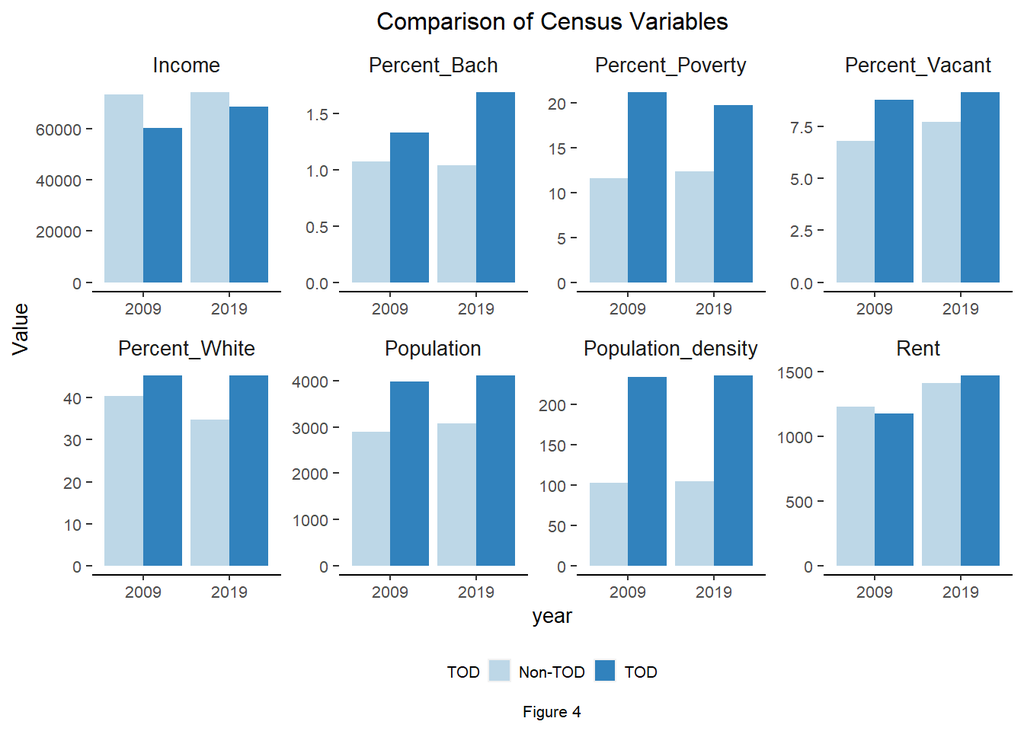

```r
allTracts_Summary %>%
  gather(Variable, Value, -year, -TOD) %>%
  ggplot(aes(year, Value, fill = TOD)) +
  geom_bar(stat = "identity", position = "dodge") +
  facet_wrap(~Variable, scales = "free", ncol=4) +
  scale_fill_manual(values = c(bluePalette5[2], bluePalette5[4])) +
  labs(title = "Comparison of Census Variables",
       caption = "Figure 4") +
  min_plotTheme()+
  theme(axis.line.x.bottom = element_line(size =0.5),
        panel.grid = element_line(size =0.5))
```

### 3-4. Graduated Symbol Maps

This chapter visualized the total resident population, average rent, and average income within 0.5 miles of each station. This allows us to understand the spatial characteristics within the TOD area.

```r
allTracts_TOD_Centroid_2019 <- allTracts_TOD %>%
  filter(year == 2019) %>%
  st_centroid()

NYStopsBuffers_NonUnion <-  st_buffer(NYStops, 2640)

NYstops_Coord <- st_coordinates(NYStops, crs ="EPSG:2263")
NYstops_Coord_sf <- cbind(NYStops, NYstops_Coord)
```

#### 3-4-1. Total Population Graduated Symbol Map

A visualization of the total number of people living within 0.5 miles of each station. You can see that the TOD area in Manhattan and Brooklyn has a relatively larger population. This distribution within the same TOD is presumed to be related to the operation of subway lines, and further research is needed.

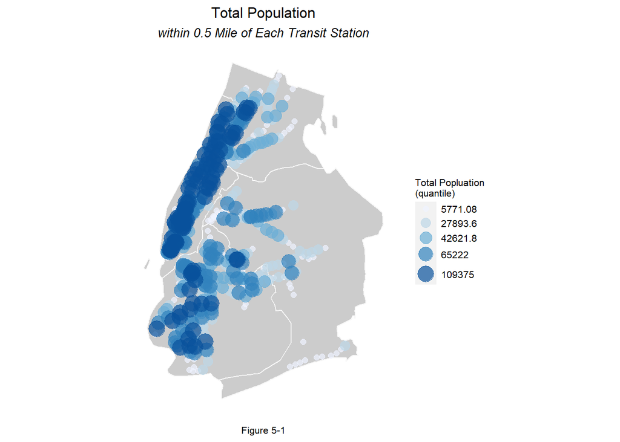

```r
# Spatial Join Every Station 0.5 mile buffer with TOD-tracts centroids

allTracts_TOD_Centroid_2019 <- allTracts_TOD %>%
  filter(year == 2019) %>%
  st_centroid()

NYStopsBuffers_NonUnion <-  st_buffer(NYStops, 2640)

NYstops_Coord <- st_coordinates(NYStops, crs ="EPSG:2263")
NYstops_Coord_sf <- cbind(NYStops, NYstops_Coord)

# Total Population within 0.5 miles

NYstops_Tracts2019_Pop <- st_join(NYStopsBuffers_NonUnion, allTracts_TOD_Centroid_2019) %>%
  group_by(name) %>%
  summarise(Station_Pop = sum(TotalPop)) %>%
  st_drop_geometry() %>%
  left_join(NYstops_Coord_sf) %>%
  na.omit() %>%
  st_drop_geometry() %>%
  st_as_sf(coords = c("X","Y"), crs ="EPSG:2263")

ggplot() +
  geom_sf(data=st_union(tracts09_MH), fill = greyPalette5[2], size = 0.5, color = greyPalette5[1]) +
  geom_sf(data=st_union(tracts09_QS), fill = greyPalette5[2], size = 0.5, color = greyPalette5[1]) +
  geom_sf(data=st_union(tracts09_BR), fill = greyPalette5[2], size = 0.5, color = greyPalette5[1]) +
  geom_sf(data=st_union(tracts09_BK), fill = greyPalette5[2], size = 0.5, color = greyPalette5[1]) +
  geom_sf(data=NYstops_Tracts2019_Pop, aes(size = q5(Station_Pop), color = q5(Station_Pop)),  alpha = 0.7) +
  scale_color_brewer(palette = "Blues",labels = qBr(NYstops_Tracts2019_Pop, "Station_Pop")) +
  scale_size_discrete(labels = qBr(NYstops_Tracts2019_Pop, "Station_Pop")) +
    labs(title = "Total Population" ,
       subtitle = 'within 0.5 Mile of Each Transit Station',
       caption = "Figure 5-1",
       size = 'Total Popluation\n(quantile)',
       color = 'Total Popluation\n(quantile)') +
  min_mapTheme() + theme(legend.position="right")
```

#### 3-4-2. Mean of Median House Rent Graduated Symbol Map

A visualization of rent averages within 0.5 miles of each station. You can see that the rent near TOD in Bronx is significantly lower than elsewhere. Further investigation is needed to analyze the cause of this.

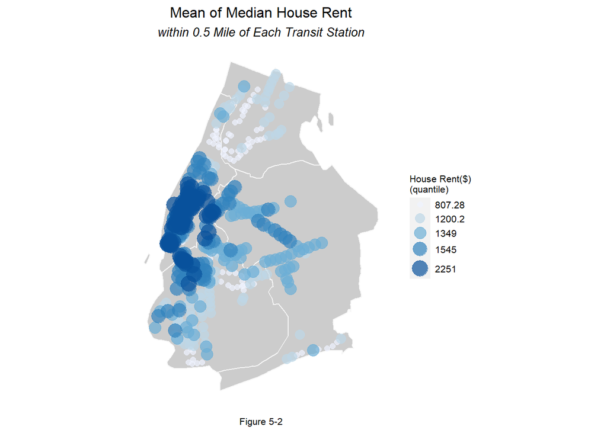

```r
# Mean of Median House Rent within 0.5 miles

NYstops_Tracts2019_Rent <- st_join(NYStopsBuffers_NonUnion, allTracts_TOD_Centroid_2019) %>%
  group_by(name) %>%
  summarise(Station_Rent = mean(MedRent)) %>%
  st_drop_geometry() %>%
  left_join(NYstops_Coord_sf) %>%
  na.omit() %>%
  st_drop_geometry() %>%
  st_as_sf(coords = c("X","Y"), crs ="EPSG:2263")

ggplot() +
  geom_sf(data=st_union(tracts09_MH), fill = greyPalette5[2], size = 0.5, color = greyPalette5[1]) +
  geom_sf(data=st_union(tracts09_QS), fill = greyPalette5[2], size = 0.5, color = greyPalette5[1]) +
  geom_sf(data=st_union(tracts09_BR), fill = greyPalette5[2], size = 0.5, color = greyPalette5[1]) +
  geom_sf(data=st_union(tracts09_BK), fill = greyPalette5[2], size = 0.5, color = greyPalette5[1]) +
  geom_sf(data=NYstops_Tracts2019_Rent, aes(size = q5(Station_Rent), color = q5(Station_Rent)),  alpha = 0.7) +
  scale_color_brewer(palette = "Blues",labels = qBr(NYstops_Tracts2019_Rent, "Station_Rent")) +
  scale_size_discrete(labels = qBr(NYstops_Tracts2019_Rent, "Station_Rent")) +
    labs(title = "Mean of Median House Rent" ,
       subtitle = 'within 0.5 Mile of Each Transit Station',
       caption = "Figure 5-2",
       size = 'House Rent($)\n(quantile)',
       color = 'House Rent($)\n(quantile)') +
  min_mapTheme() + theme(legend.position="right")
```

#### 3-4-3. Mean of Median House Hold Income Graduated Symbol Map

It is a visualization of the average of middle income within 0.5 miles of each station. The distribution of the ‘3-4-2. Mean of Median House Rent Graduated Symbol Map’ is almost identical. However, we can see the difference between income and rent in some areas of the Bronx, and further investigation is needed to see how much they will be able to pay for the increased rent if TOD development in the Bronx area takes place in the future.

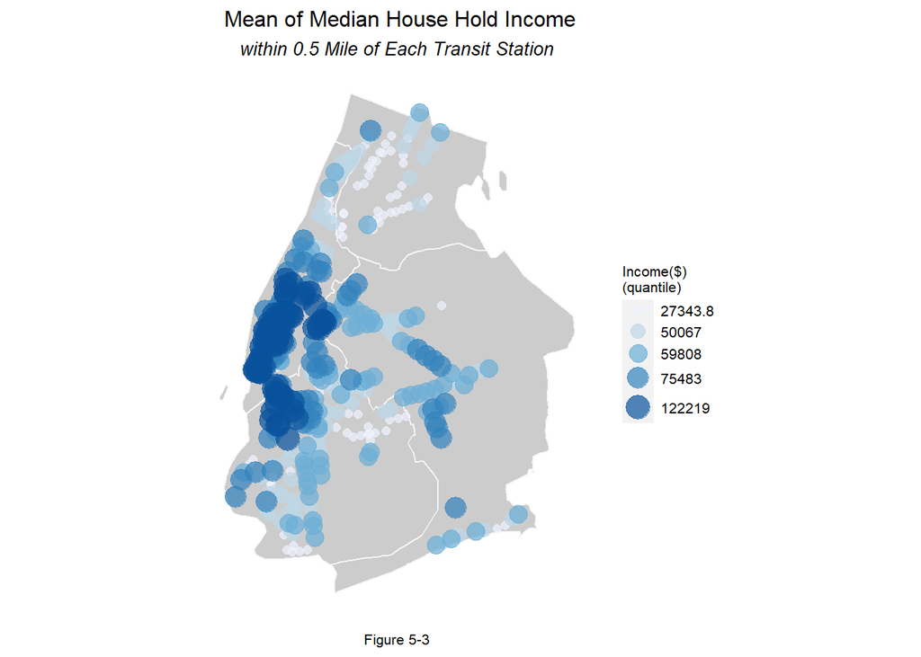

```r
# Mean of Median House Hold Income within 0.5 miles

NYstops_Tracts2019_Inc <- st_join(NYStopsBuffers_NonUnion, allTracts_TOD_Centroid_2019) %>%
  group_by(name) %>%
  summarise(Station_Inc = mean(MedHHInc)) %>%
  st_drop_geometry() %>%
  left_join(NYstops_Coord_sf) %>%
  na.omit() %>%
  st_drop_geometry() %>%
  st_as_sf(coords = c("X","Y"), crs ="EPSG:2263")

ggplot() +
  geom_sf(data=st_union(tracts09_MH), fill = greyPalette5[2], size = 0.5, color = greyPalette5[1]) +
  geom_sf(data=st_union(tracts09_QS), fill = greyPalette5[2], size = 0.5, color = greyPalette5[1]) +
  geom_sf(data=st_union(tracts09_BR), fill = greyPalette5[2], size = 0.5, color = greyPalette5[1]) +
  geom_sf(data=st_union(tracts09_BK), fill = greyPalette5[2], size = 0.5, color = greyPalette5[1]) +
  geom_sf(data=NYstops_Tracts2019_Inc, aes(size = q5(Station_Inc), color = q5(Station_Inc)),  alpha = 0.7) +
  scale_color_brewer(palette = "Blues",labels = qBr(NYstops_Tracts2019_Inc, "Station_Inc")) +
  scale_size_discrete(labels = qBr(NYstops_Tracts2019_Inc, "Station_Inc")) +
    labs(title = " Mean of Median House Hold Income" ,
       subtitle = 'within 0.5 Mile of Each Transit Station',
       caption = "Figure 5-3",
       size = 'Income($)\n(quantile)',
       color = 'Income($)\n(quantile)') +
  min_mapTheme() + theme(legend.position="right")
```

### 3-5. Mean Rent Line Graph

A graph that visualizes the rent average by distance from each station. From this graph, you can see that the rent increases as the distance increases from 1 mile later. This may reflect a tendency to prefer living in the suburbs to living in urban areas, or rent may have become expensive because larger houses are located as the distance from the subway station increases. We believe further research is needed on this **However, the fact remains that rents within the TOD area of 0.5 miles have risen over time.**

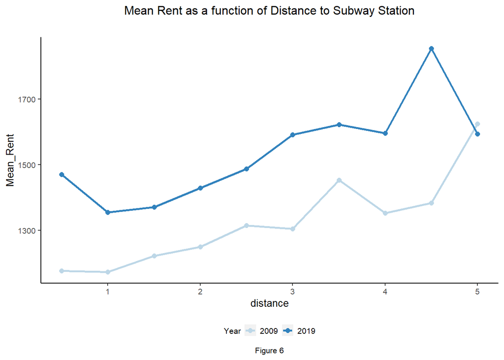

```r
# Generate MBR
NYStops_MRB <- MBR(st_union(NYStops),
                                maxDistance = 29040,
                                interval =  2640)

# Spatial join Tract19 data with NYstops_MRB
tracts_MBR <- allTracts %>%
  select(GEOID, year) %>%
  st_centroid() %>%
  st_join(NYStops_MRB, join = st_intersects) %>%
  st_drop_geometry() %>%
  left_join(dplyr::select(allTracts, GEOID, MedRent, year),
            by=c("GEOID"="GEOID", "year"="year")) %>%
  st_sf() %>%
  mutate(distance = distance / 5280) #convert to miles

tracts_rings_summary <- st_drop_geometry(tracts_MBR) %>%
    group_by(distance, year) %>%
    summarize(Mean_Rent = mean(MedRent, na.rm=T))

ggplot(tracts_rings_summary,
       aes(distance, Mean_Rent, color=year)) +
  geom_point(size=2) +
  geom_line(size=1) +
  scale_color_manual(values = c(bluePalette5[2], bluePalette5[4])) +
  min_plotTheme()+
  theme(axis.line.x.bottom = element_line(size =0.5),
        axis.line.y.left = element_line(size =0.5),
        panel.grid = element_line(size =0.5))+
  labs(title = "Mean Rent as a function of Distance to Subway Station" ,
       subtitle = '',
       caption = "Figure 6",
       color = 'Year')
```

## Ⅳ. Conclusions

**In conclusion, it seems clear that New Yorkers are willing to pay higher rents in TOD areas. Although this preference exists, the tendency to increase vacancy rates in TOD areas may cause another housing problem in the future. In particular, as the proportion of students living increases, it is necessary to consider urban policies such as subsidies and affordable housing related to these classes.**

In addition, the Bronx will be suitable for future TOD development areas. While further study into this will be needed, the balance of income and rent for residents in the Bronx area now appears to be more stable than in other areas. Increasing the density of cities and improving public transportation services through TOD development can be another driving force for urban growth.